# topiclabels: An R Package for Automated Topic Labeling Using (Large) Language Models

Jonas Rieger, TU Dortmund University, rieger@statistik.tu-dortmund.de

Fritz Peters, University of Sheffield, fpeters3@sheffield.ac.uk

Andreas Fischer, Forschungsinstitut Betriebliche Bildung (f-bb), andreasfischer1985@web.de

Tim Lauer, Leibniz Institute for Psychology (ZPID), tl@leibniz-psychology.org

André Bittermann, Leibniz Institute for Psychology (ZPID), abi@leibniz-psychology.org

# Summary

Our proposed R package leverages (Large) Language Models (LLM) for automatic topic labeling. The main function `label_topics()` takes a list of top terms as input and generates a label for each topic. Hence, it is complementary to any topic modeling package that produces a list of top terms for each topic.

While human judgement is indispensable for topic validation (i.e., inspecting top terms and most representative documents), automatic topic labeling can be a valuable tool for researchers in scenarios such as:

1. A **large number of topics** need to be labeled (e.g., topic models with thousands of topics, models with changing topic content over time (see [RollingLDA](https://github.com/JonasRieger/rollinglda)), or for evaluating the results for many different values of *k*)
2. The LLM can provide a **first approximation** of the topic, which can then be refined by human coders.
3. It may also be of help as a **second opinion** in cases where human coders disagree or to identify topics that are hard to interpret.

Hence, the goal of the proposed package is not to replace human judgment and validation to topic modeling results, but to support researchers during this process.

Currently, the HuggingFace API is used to access the LLM. The default model is [`mistralai/Mixtral-8x7B-Instruct-v0.1`](https://huggingface.co/mistralai/Mixtral-8x7B-Instruct-v0.1), but the user can also specify other models.

In the following, we compare the automatically generated topic labels with the labels of human coders published in various topic modeling studies.

*Note:* Generative AI (i.e., GitHub Copilot) was used for coding assistance.

# Setup

## Set file path

```r
path <- "your_path"
```

## Load the package and API token

```r
# CRAN version:
install.packages("topiclabels")

# development version:
devtools::install_github("PetersFritz/topiclabels")
```

```r
# load package
library("topiclabels")
```

```r
# Load your HuggingFace token.
# HOW TO GET A FREE TOKEN: see
# https://huggingface.co/docs/hub/security-tokens
token <- readLines("HuggingFace_token.txt")
```

## Examples

The following examples illustrate how to use the `label_topics()` function:

```r
# label a topics
label_topics(c("zidane", "figo", "kroos"), token = token)
```

```
## Labeling 1 topic(s) using the language model mistralai/Mixtral-8x7B-Instruct-v0.1 and a Huggingface API token.
```

```
## Labeling process finished
```

```
## lm_topic_labels object generated using mistralai/Mixtral-8x7B-Instruct-v0.1
##  1: Real Madrid Midfielders [zidane, figo, kroos]
```

```r
# label two topics
label_topics(list(c("zidane", "figo", "kroos"), c("gas", "power", "wind")), token = token)
```

```
## Labeling 2 topic(s) using the language model mistralai/Mixtral-8x7B-Instruct-v0.1 and a Huggingface API token.
```

```
## Labeling process finished
```

```
## lm_topic_labels object generated using mistralai/Mixtral-8x7B-Instruct-v0.1
##  1: Real Madrid Midfielders [zidane, figo, kroos]
##  2: Renewable Energy [gas, power, wind]
```

```r
# Specify the language model to be used
label_topics(list(c("zidane", "figo", "kroos"), c("gas", "power", "wind")), model = "HuggingFaceH4/zephyr-7b-beta", token = token)
```

```
## Labeling 2 topic(s) using the language model HuggingFaceH4/zephyr-7b-beta and a Huggingface API token.
```

```
## Labeling process finished
```

```
## lm_topic_labels object generated using HuggingFaceH4/zephyr-7b-beta
##  1: Real Madrid midfielders [zidane, figo, kroos]
##  2: Renewable Energy [gas, power, wind]
```

```r
# Provide the topical context of the corpus
label_topics(c("gas", "power", "wind"), context = "texts about cars and their features", token = token)
```

```
## Labeling 1 topic(s) using the language model mistralai/Mixtral-8x7B-Instruct-v0.1 and a Huggingface API token.
```

```
## Labeling process finished
```

```
## lm_topic_labels object generated using mistralai/Mixtral-8x7B-Instruct-v0.1
##  1: Fuel Efficiency and Power [gas, power, wind]
```

# How to use the topiclabels package with other topic modeling packages

Our proposed R package can be used with other topic modeling packages as well. The only requirement is that the topic modeling package provides a function to extract the top terms of each topic. The user can then provide these top terms to the `label_topics` function. The `label_topics` function will then generate the topic labels based on the provided top terms.

In the following, we will illustrate this for different popular R packages (see Wiedemann, 2002, http://dx.doi.org/10.5771/1615-634X-2022-3-286)

## topicmodels

We use the example from the package vignette (Grün & Hornik, 2024): https://cran.r-project.org/web/packages/topicmodels/vignettes/topicmodels.pdf

```r
# load data
library(topicmodels)
data("JSS_papers", package = "topicmodels")

# transform to corpus
library(tm)
corpus <- Corpus(VectorSource(unlist(JSS_papers[, "description"])))
JSS_dtm <- DocumentTermMatrix(corpus,
 control = list(stemming = TRUE, stopwords = TRUE, minWordLength = 3,
 removeNumbers = TRUE, removePunctuation = TRUE))
```

```r
# run topic model
jss_TM <- LDA(JSS_dtm, k = 30, control = list(seed = 2010))

# save
saveRDS(jss_TM, file = paste0(path, "/jss_TM.RDS"))
```

```r
# get topics
topics_topicmodels <- topicmodels::terms(jss_TM, 5)
topics_topicmodels[,1:5]
```

```
##      Topic 1   Topic 2     Topic 3   Topic 4   Topic 5
## [1,] "network" "algorithm" "data"    "use"     "cluster"
## [2,] "data"    "packag"    "statist" "www"     "model"
## [3,] "model"   "data"      "use"     "statist" "packag"
## [4,] "packag"  "provid"    "method"  "java"    "method"
## [5,] "use"     "function"  "infer"   "can"     "can"
```

These top terms are used as input for our `label_topics` function:

```r
# label_topics
labels_topicmodels <- label_topics(topics_topicmodels, context = "Journal of Statistical Software", token = token)
```

```
## Labeling 30 topic(s) using the language model mistralai/Mixtral-8x7B-Instruct-v0.1 and a Huggingface API token.
```

```
## Labeling process finished
```

```r
labels_topicmodels
```

```
## lm_topic_labels object generated using mistralai/Mixtral-8x7B-Instruct-v0.1
##  1: Network Analysis [network, data, model, packag, use]
##  2: Data Analysis Tools [algorithm, packag, data, provid, function]
##  3: Statistical Methods [data, statist, use, method, infer]
##  4: Statistical Software [use, www, statist, java, can]
##  5: Clustering Methods [cluster, model, packag, method, can]
##  6: Data Visualization [packag, model, use, method, graphic]
##  7: Data Analysis and Visualization [data, use, packag, imag, method]
##  8: Smooth Model Fitting [use, model, smooth, fit, program]
##  9: Statistical Modeling [model, estim, packag, data, function]
##  10: Tumor Detection Tools [test, tool, polyk, tumor, wave]
##  11: Modeling functions [model, packag, function, fit, provid]
##  12: Statistical programming in Lisp [use, statist, packag, can, lispstat]
##  13: Software packages and solutions [code, packag, solv, use, problem]
##  14: Regression Model [model, variabl, standard, confid, regress]
```

[output cut: 16 more lines]

## stm

We use the example from the package vignette (Roberts et al., 2019): https://cran.r-project.org/web/packages/stm/vignettes/stmVignette.pdf

```r
data <- read.csv("https://raw.githubusercontent.com/dondealban/learning-stm/master/data/poliblogs2008.csv")
```

```r
# preprocessing
library(stm)
processed <- textProcessor(data$documents, metadata = data)
```

```r
# corpus preparation
out <- prepDocuments(processed$documents, processed$vocab, processed$meta, lower.thresh = 15)
```

```r
# stm topic model
poliblogPrevFit <- stm(documents = out$documents, vocab = out$vocab,
 K = 20, prevalence =~ rating + s(day),
 max.em.its = 75, data = out$meta,
 init.type = "Spectral")

# save
saveRDS(poliblogPrevFit, file = paste0(path, "/poliblogPrevFit.RDS"))
```

```r
# get topics
topics_stm <- stm::labelTopics(poliblogPrevFit, c(3, 7, 20))

# show the topics 3, 7, and 20 (as in vignette)
stm::labelTopics(poliblogPrevFit, c(3, 7, 20))
```

```
## Topic 3 Top Words:
##       Highest Prob: obama, barack, campaign, biden, polit, will, debat
##       FREX: ayer, barack, obama, wright, biden, jeremiah, joe
##       Lift: oct, goolsbe, ayerss, ayr, bernadin, ayer, annenberg
##       Score: oct, obama, barack, ayer, wright, campaign, biden
## Topic 7 Top Words:
##       Highest Prob: palin, governor, sarah, state, alaska, polit, senat
##       FREX: blagojevich, palin, sarah, rezko, alaska, governor, gov
##       Lift: jindal, blagojevich, juneau, monegan, blago, burri, wasilla
##       Score: monegan, palin, blagojevich, sarah, alaska, rezko, governor
## Topic 20 Top Words:
##       Highest Prob: bush, presid, administr, said, hous, white, report
##       FREX: cheney, tortur, cia, administr, interrog, bush, perino
##       Lift: addington, fratto, perino, mcclellan, feith, plame, cheney
##       Score: addington, bush, tortur, perino, cia, cheney, administr
```

For STM topics, you can choose the type of term profiles. STM offers “prob”, “frex”, “lift”, “score” (see [stm vignette](https://cran.r-project.org/web/packages/stm/vignettes/stmVignette.pdf)), which you can specify using the `stm_type` argument. By default, “prob” is used.

```r
# label_topics: default stm_type ("prob")
labels_stm <- label_topics(topics_stm, context = "blogposts about American
politics", token = token)
```

```
## Labeling 20 topic(s) using the language model mistralai/Mixtral-8x7B-Instruct-v0.1 and a Huggingface API token.
```

```
## Labeling process finished
```

```r
labels_stm
```

```
## lm_topic_labels object generated using mistralai/Mixtral-8x7B-Instruct-v0.1
##  1: Obama's Lead in Polls [obama, poll, mccain, voter, state, democra...]
##  2: Public Opinion on Politics [peopl, think, polit, like, right, just, one]
##  3: Obama-Biden Political Campaign [obama, barack, campaign, biden, polit, wil...]
##  4: Informal language and negation [get, one, like, just, want, can, dont]
##  5: Energy Policy and Prices [oil, energi, will, price, drill, gas, product]
##  6: US Political Campaigns [elect, vote, voter, campaign, republican, ...]
##  7: Alaska Governor Sarah Palin [palin, governor, sarah, state, alaska, pol...]
##  8: Government Finances [tax, money, million, financi, govern, spen...]
##  9: Media and News [media, time, report, news, stori, press, new]
##  10: Congressional Legislation [democrat, senat, bill, republican, vote, h...]
##  11: Legal and Court Proceedings [law, court, state, right, case, rule, legal]
##  12: Iraq War and Military [iraq, war, militari, iraqi, troop, forc, will]
##  13: Iranian Nuclear Program [iran, nuclear, world, state, nation, will,...]
##  14: American people's work and care [will, american, america, peopl, care, work...]
##  15: Terrorism in Middle East [terrorist, attack, israel, kill, terror, g...]
##  16: Diverse Life Experiences [one, will, film, women, allah, life, day]
##  17: Global Warming and Research [global, warm, univers, abort, studi, resea...]
##  18: John McCain's Campaign [mccain, john, said, campaign, sen, say, think]
##  19: Hillary Clinton's Democratic Primary Campaign [clinton, hillari, will, democrat, primari,...]
##  20: Bush Administration [bush, presid, administr, said, hous, white...]
```

```r
# label_topics: frex
labels_stm_frex <- label_topics(topics_stm, stm_type = "frex", context = "blogposts about American politics", token = token)
```

```
## Labeling 20 topic(s) using the language model mistralai/Mixtral-8x7B-Instruct-v0.1 and a Huggingface API token.
```

```
## Labeling process finished
```

```r
labels_stm_frex
```

```
## lm_topic_labels object generated using mistralai/Mixtral-8x7B-Instruct-v0.1
##  1: Pennsylvania-Virginia Polling [poll, pennsylvania, virginia, percent, mar...]
##  2: Religious Conservatism [church, digbi, liber, black, linktocomment...]
##  3: Obama's Pastor Controversy [ayer, barack, obama, wright, biden, jeremi...]
##  4: Negative Sentiments [cant, eastern, doesnt, isnt, didnt, clip, ...]
##  5: Energy and Oil Prices [drill, oil, mugab, energi, gas, price, pro...]
##  6: Minnesota Senate Recount [franken, coleman, ballot, registr, acorn, ...]
##  7: Illinois and Alaska Governors [blagojevich, palin, sarah, rezko, alaska, ...]
##  8: Housing finance [financi, loan, fanni, mortgag, taxpay, fre...]
##  9: Matthew O'Reilly Media Coverage [matthew, media, journalist, coverag, stori...]
##  10: Democratic Leadership [legisl, pelosi, reid, bipartisan, fisa, na...]
##  11: Constitutional Law [court, illeg, law, constitut, prosecut, le...]
##  12: Iraqi Politics and Security [maliki, petraeus, iraqi, baghdad, iraq, tr...]
##  13: Middle East Nuclear Tensions [russian, russia, iran, nuclear, iranian, p...]
##  14: Healthcare and Labor [health, care, union, educ, america, job, w...]
##  15: Middle East Politics [palestinian, hama, musharraf, pakistan, pa...]
##  16: Islamic Religious Film [film, allah, muhammad, girl, qur, vers, un...]
##  17: Climate Change [warm, abort, scientist, climat, scientif, ...]
##  18: Conservative Pundits [mccain, raz, john, sen, clark, hanniti, kr...]
##  19: Clinton vs. Romney in Primaries [hillari, clinton, huckabe, deleg, romney, ...]
##  20: Bush-era Torture Policies [cheney, tortur, cia, administr, interrog, ...]
```

In the package [vignette](https://cran.r-project.org/web/packages/stm/vignettes/stmVignette.pdf) (page 19), Topic 3 is labeled as “Obama”, Topic 7 as “Sarah Palin”, and Topic 20 as “Bush Presidency”.

## BTM

We use the example from the package reference manual (Wijffels, 2023): https://cran.r-project.org/web/packages/BTM/BTM.pdf

```r
# load data
library(udpipe)
data("brussels_reviews_anno", package = "udpipe")

# prepare data
x <- subset(brussels_reviews_anno, language == "nl")
x <- subset(x, xpos %in% c("NN", "NNP", "NNS"))
x <- x[, c("doc_id", "lemma")]
```

```r
library(BTM)
set.seed(123456)
BTM_model <- BTM(x, k = 5, alpha = 1, beta = 0.01, iter = 10, trace = TRUE)

saveRDS(BTM_model, file = paste0(path, "/BTM_model.RDS"))

topics_btm <- terms(BTM_model) # causes issues when knitting, thus saved here and loaded below
saveRDS(topics_btm, file = paste0(path, "/topics_btm.RDS"))
```

```r
# get topic terms
topics_btm <- terms(BTM_model)
```

```r
# show topic 1
topics_btm[[1]]
```

|  | token | probability |
| --- | --- | --- |
| 1 | appartement | 0.04468092 |
| 2 | brussel | 0.03059687 |
| 3 | huis | 0.02238927 |
| 4 | kamer | 0.01826118 |
| 5 | centrum | 0.01612429 |

These top terms are used as input for our `label_topics` function:

```r
# label_topics
labels_btm <- label_topics(topics_btm, context = "Reviews of AirBnB customers on Brussels address locations", token = token)
```

```
## Labeling 5 topic(s) using the language model mistralai/Mixtral-8x7B-Instruct-v0.1 and a Huggingface API token.
```

```
## Labeling process finished
```

```r
labels_btm
```

```
## lm_topic_labels object generated using mistralai/Mixtral-8x7B-Instruct-v0.1
##  1: Brussels city center apartments [appartement, brussel, huis, kamer, centrum]
##  2: Brussels apartment rental [appartement, brussel, buurt, verblijf, huis]
##  3: Central Brussels Apartments [appartement, brussel, kamer, aanrader, cen...]
##  4: Brussels apartment rental [appartement, brussel, kamer, badkamer, bed]
##  5: Brussels city center apartments [appartement, brussel, centrum, kamer, locatie]
```

As we can see, the LLM `mistralai/Mixtral-8x7B-Instruct-v0.1` can also handle Dutch top terms and generates English labels. The labels are relatively similar, but so are the top terms of the BTM example data.

## ldaPrototype

We use the example from the package GitHub repository (see also Rieger, 2020): https://github.com/JonasRieger/ldaPrototype

```r
# load data
library(ldaPrototype)
data(reuters_docs)
data(reuters_vocab)
```

```r
# ldaPrototype topic model
res = LDAPrototype(docs = reuters_docs, vocabLDA = reuters_vocab, n = 4, K = 10, seeds = 1:4)

# save
saveRDS(res, file = paste0(path, "/res.RDS"))
```

```r
# get topics
library(ldaPrototype)
topics_ldaproto <- tosca::topWords(getTopics(getLDA(res)), 10)

topics_ldaproto
```

```
##       [,1]       [,2]     [,3]         [,4]          [,5]       [,6]
##  [1,] "billion"  "sales"  "technology" "bankamerica" "share"    "company"
##  [2,] "dlrs"     "dlrs"   "told"       "debt"        "quarter"  "said"
##  [3,] "week"     "york"   "will"       "analysts"    "company"  "inc"
##  [4,] "compared" "times"  "licensing"  "interest"    "said"     "shares"
##  [5,] "said"     "new"    "cranston"   "stock"       "chemlawn" "common"
##  [6,] "reserve"  "avoid"  "evans"      "banking"     "earnings" "units"
##  [7,] "bank"     "cocoa"  "exports"    "brazil"      "fourth"   "offering"
##  [8,] "mln"      "cover"  "authority"  "co"          "waste"    "corp"
##  [9,] "new"      "senate" "reporters"  "said"        "fiscal"   "reuter"
## [10,] "banks"    "tax"    "control"    "first"       "cash"     "systems"
##       [,7]     [,8]        [,9]       [,10]
##  [1,] "vs"     "peladeau"  "orders"   "total"
##  [2,] "cts"    "paper"     "report"   "offered"
##  [3,] "mln"    "two"       "reagan"   "bid"
##  [4,] "shr"    "newspaper" "capital"  "river"
##  [5,] "net"    "quebecor"  "november" "wheat"
##  [6,] "profit" "companies" "tower"    "feb"
##  [7,] "loss"   "said"      "tax"      "prev"
##  [8,] "revs"   "daily"     "pct"      "nil"
##  [9,] "record" "will"      "fed"      "apr"
## [10,] "march"  "new"       "public"   "mar"
```

These top terms are used as input for our `label_topics` function.

```r
# label_topics
labels_ldaproto <- label_topics(topics_ldaproto, context = "Reuters news data", token = token)
```

```
## Labeling 10 topic(s) using the language model mistralai/Mixtral-8x7B-Instruct-v0.1 and a Huggingface API token.
```

```
## Labeling process finished
```

```r
labels_ldaproto
```

```
## lm_topic_labels object generated using mistralai/Mixtral-8x7B-Instruct-v0.1
##  1: Bank Reserves and Liquidity [billion, dlrs, week, compared, said, reser...]
##  2: New York Sales Tax [sales, dlrs, york, times, new, avoid, coco...]
##  3: Technology Licensing and Control [technology, told, will, licensing, cransto...]
##  4: Bank of America's debt and stock [bankamerica, debt, analysts, interest, sto...]
##  5: Company Earnings Report [share, quarter, company, said, chemlawn, e...]
##  6: Common Stock Offering [company, said, inc, shares, common, units,...]
##  7: Quarterly financial results [vs, cts, mln, shr, net, profit, loss, revs...]
##  8: Quebecor's newspaper companies [peladeau, paper, two, newspaper, quebecor,...]
##  9: Reagan's Tax Policy [orders, report, reagan, capital, november,...]
##  10: Agricultural Commodities Trading [total, offered, bid, river, wheat, feb, pr...]
```

# Performance evaluation

To evaluate the performance of the `label_topics()` function, we compare the automatically generated labels with human labels from various studies. Inclusion criteria for the studies were:

- Top terms and human labels are provided
- English language

## Retrieve human labels

The topics labeled by humans were taken from the following studies:

- **Bittermann et al.** [(2023](https://doi.org/10.1007/s10648-023-09775-9). Context: Research on prior knowledge and learning in the fields of psychology and educational science.
- **Li et al.** [(2023](https://doi.org/10.31235/osf.io/23x4m). Context: Sociology.
- **Weber** [(2021)](https://doi.org/10.1177/21582440211061567). Context: How 50-year-olds imagine their future.
- **Kwon & Nguyen** [(2023)](https://doi.org/10.1177/0739456X231156827). Context: Racial equity in urban planning.
- **Sharma et al.** [(2021)](https://doi.org/10.1016/j.ijinfomgt.2021.102316). Context: Information Management
- **Phillips et al.** [(2023)](https://doi.org/10.1016/j.socscimed.2023.116144). Context: Suicide
- **Tonidandel et al.** [(2022)](https://doi.org/10.1016/j.leaqua.2021.101576). Context: Leadership
- **Dwivedi et al.** [(2023)](https://doi.org/10.1016/j.techfore.2023.122579). Context: Artificial Intelligence
- **Heiberger et al.** [(2021)](https://doi.org/10.1177/00031224211056267). Context: Effects of specialization on academic career success

We provide all labels and top terms of the original studies in [Table_human_labels](https://docs.google.com/spreadsheets/d/1UcumvMI-j4ehNUVF-_DWc5cdkOsM8QbTGOPJ10wGZTw/edit?usp=sharing).

```r
# Load table with human labels
library(googlesheets4)
gs4_deauth() # no authentication needed for public sheets
human_labels <- read_sheet("1UcumvMI-j4ehNUVF-_DWc5cdkOsM8QbTGOPJ10wGZTw")
as.data.frame(human_labels[1:5, c(1,3:4)])
```

| Study | Top_Terms | Human_Label |
| --- | --- | --- |
| Bittermann 2023 | literacy, reading instruction, organizer, strategy, reading strategies | Reading Instruction |
| Bittermann 2023 | text, expository, passage, comprehension, reading comprehension | Reading Comprehension |
| Bittermann 2023 | english, second language learning, language, efl, english (second language) | Foreign Language |
| Bittermann 2023 | achievement, score, group, posttest, pretest | Academic Achievement |
| Bittermann 2023 | learn, feedback, tutor, scaffold, selfregulated | Self-Regulated Learning |

## Standard labeling

```r
LLM_labels <- label_topics(as.list(human_labels$Top_Terms), token = token)

# save
saveRDS(LLM_labels, file = paste0(path, "/LLM_labels.RDS"))
```

```r
# Compare results
example <- cbind(head(human_labels$Human_Label, 10), head(LLM_labels$labels, 10))
colnames(example) <- c("Human_Label", "LLM_Label")
example
```

```
##       Human_Label
##  [1,] "Reading Instruction"
##  [2,] "Reading Comprehension"
##  [3,] "Foreign Language"
##  [4,] "Academic Achievement"
##  [5,] "Self-Regulated Learning"
##  [6,] "Multimedia Learning"
##  [7,] "Information Literacy"
##  [8,] "Teacher Knowledge"
##  [9,] "Student Knowledge in Higher Education"
## [10,] "Organizational Knowledge in Higher Education"
##       LLM_Label
##  [1,] "Reading Instruction Strategies"
##  [2,] "Reading Comprehension"
##  [3,] "English Language Learning"
##  [4,] "Pre/Post Test Scores"
##  [5,] "Self-regulated learning"
##  [6,] "Multimedia Loading and Transfer"
##  [7,] "Online Navigation"
##  [8,] "Preservice Teacher Pedagogy"
##  [9,] "Chemistry Lecture and Lab"
## [10,] "Engineering Education"
```

### Compute similarity of label sentence embeddings

To quantify the similarity between the human labels and the labels generated by the LLM, we use the [`llmrails/ember-v1`](https://huggingface.co/llmrails/ember-v1) model to transform each label into a sentence embedding. We then calculate the cosine similarity between the embeddings of the human labels and the LLM labels.

The following function retrieves the sentence embeddings for a given list of labels using the HuggingFace API:

```r
# compare semantic similarity of labels using sentence embeddings
# using the HuggingFace API and the code from:
# https://github.com/AndreasFischer1985/code-snippets/blob/master/R/huggingface_SentenceEmbeddingsTest.R

get_embeddings <- function(prompts, model_id = "llmrails/ember-v1", api_token = token) {

  require("httr")
  e=list()
  t0=Sys.time()
  e=list()

  for(i in 1:length(prompts)){
    print(paste0(i,"/",length(prompts)," started at ",Sys.time()))
    payload=prompts[i]
    #payload = "Roses are red"
    url=paste0("https://api-inference.huggingface.co/models/",model_id)
    post=httr::POST(url=url, body=list("inputs"= payload),
        httr::add_headers(.headers=c("X-Wait-For-Model"="true","X-Use-Cache"="false")),
    httr::add_headers(.headers=c("Authorization"=paste("Bearer",api_token))),
    encode="json")
    x=httr::content(post)
    print(length(x[[1]][[1]]))
    e[[i]]=x
  }

  t1=Sys.time()
  t1-t0
  #sapply(e,length)

  sentenceEmbeddings = lapply(e,function(f){
    #x=do.call(cbind,f[[1]])
    #x=apply(x,2,as.numeric)
    #rowMeans(x) # Mean-Pooling der Token-Embeddings
    unlist(f)
  })
  embeddings_a_4=do.call(rbind,sentenceEmbeddings)

  return(embeddings_a_4)

}
```

```r
# get embeddings
human_labels_embeddings <- get_embeddings(human_labels$Human_Label)
LLM_labels_embeddings <- get_embeddings(LLM_labels$labels)

# save
saveRDS(human_labels_embeddings, file = paste0(path, "/human_labels_embeddings.RDS"))
saveRDS(LLM_labels_embeddings, file = paste0(path, "/LLM_labels_embeddings.RDS"))
```

```r
# compute pairwise cosine similarity
sims <- vector()
for (i in 1:nrow(human_labels_embeddings)){
  sims[i] <- lsa::cosine(as.numeric(human_labels_embeddings[i,]), as.numeric(LLM_labels_embeddings[i,]))
}
```

```r
# result data frame
res <- data.frame(Study = human_labels$Study,
                  Topic_Number = human_labels$Topic_Number,
                  Human_Label = human_labels$Human_Label,
                  LLM_Label = LLM_labels$labels,
                  Similarity = sims)
```

### Overall similarity

```r
summary(res$Similarity)
```

```
##    Min. 1st Qu.  Median    Mean 3rd Qu.    Max.
##  0.3936  0.5857  0.6679  0.6752  0.7449  1.0000
```

Overall, the mean cosine similarity between the human labels and the LLM labels is 0.68, indicating a moderate similarity between the two sets of labels. At least one human label was perfectly matched by the LLM (cosine similarity = 1), while the lowest similarity was 0.39.

Let’s have a closer look at the performance for the different studies:

### Results by study

```r
# show mean cosine similarity by study
aggregate(Similarity ~ Study, data = res, FUN = mean)
```

| Study | Similarity |
| --- | --- |
| Bittermann 2023 | 0.7257430 |
| Dwivedi 2023 | 0.7493252 |
| Heiberger 2021 | 0.6544378 |
| Kwon 2023 | 0.6981256 |
| Li 2023 | 0.6315839 |
| Phillips 2023 | 0.6504330 |
| Sharma 2021 | 0.7742655 |
| Tonidandel 2022 | 0.6708855 |
| Weber 2021 | 0.6322067 |

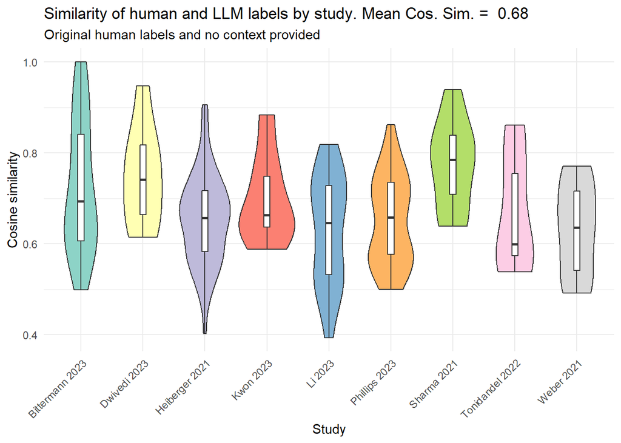

```r
library(ggplot2)
ggplot(res, aes(x = Study, y = Similarity, fill = Study)) +
  geom_violin() +
  geom_boxplot(width = 0.1, fill = "white") +
  scale_fill_brewer(palette = "Set3") + # Use a predefined color palette
  theme_minimal() +
  labs(title = paste("Similarity of human and LLM labels by study. Mean Cos. Sim. = ", round(mean(res$Similarity), 2)),
       subtitle = "Original human labels and no context provided",
       x = "Study",
       y = "Cosine similarity") +
  guides(fill = "none") +
  theme(axis.text.x = element_text(angle = 45, hjust = 1))
```

As we can see, there is variation in the similarity between human and LLM labels across the different studies. Some studies show higher similarity than others, indicating that the LLM’s performance may vary depending on the topic - or the quality of the human labels.

### Comparison with ChatGPT-generated Labels in Li et al. (2023)

Li et al. (2023) used ChatGPT to generate labels for the same topics. Let’s compare their results with our LLM labels.

```r
# ChatGPT labels, see https://doi.org/10.31235/osf.io/23x4m
Li_chatgpt <- c(
  "Indie Rock Music",
  "Political Transformation",
  "Syrian conflict and extremist groups",
  "Storytelling or Narration",
  "Activism and Resistance",
  "Financial Risk and Instability",
  "Monetary policy tools and actions of the Federal Reserve",
  "Financial performance",
  "Cultural and political discourse in global and local contexts",
  "Wildlife or Nature",
  "Insurance industry",
  "Winter weather and climate forecasts",
  "Government and Legislative Affairs",
  "Social structure and organization in communities and groups",
  "Golf course geography and topography",
  "Technology companies and outdoor activities",
  "Corporate Finance/Earnings Report",
  "Afghan War and Politics",
  "Islamic Jihad and its pillars",
  "Conspiracy theories surrounding QAnon movement and the COVID-19 pandemic"
)
```

```r
# Create embeddings
Li_chatgpt_embeddings <- get_embeddings(Li_chatgpt)
saveRDS(Li_chatgpt_embeddings, file = paste0(path, "/Li_chatgpt_embeddings.RDS"))
```

```r
# Compute similarities with LLM_labels
ind_Li <- which(human_labels$Study == "Li 2023")
LLM_labels_embeddings_Li <- LLM_labels_embeddings[ind_Li,]
human_labels_embeddings_Li <- human_labels_embeddings[ind_Li,]

sims_LLM_chatgpt <- vector()
for (i in 1:nrow(Li_chatgpt_embeddings)){
  sims_LLM_chatgpt[i] <- lsa::cosine(as.numeric(Li_chatgpt_embeddings[i,]), as.numeric(LLM_labels_embeddings_Li[i,]))
}

sims_human_chatgpt <- vector()
for (i in 1:nrow(Li_chatgpt_embeddings)){
  sims_human_chatgpt[i] <- lsa::cosine(as.numeric(Li_chatgpt_embeddings[i,]), as.numeric(human_labels_embeddings_Li[i,]))
}
```

```r
# violin plot of similarities
res_Li <- data.frame(Human_Label = human_labels$Human_Label[ind_Li],
                      ChatGPT_Label = Li_chatgpt,
                      LLM_Label = LLM_labels$labels[ind_Li],
                      Similarity_LLM_ChatGPT = sims_LLM_chatgpt,
                      Similarity_Human_ChatGPT = sims_human_chatgpt,
                      Similarity_Human_LLM = sims[ind_Li])
```

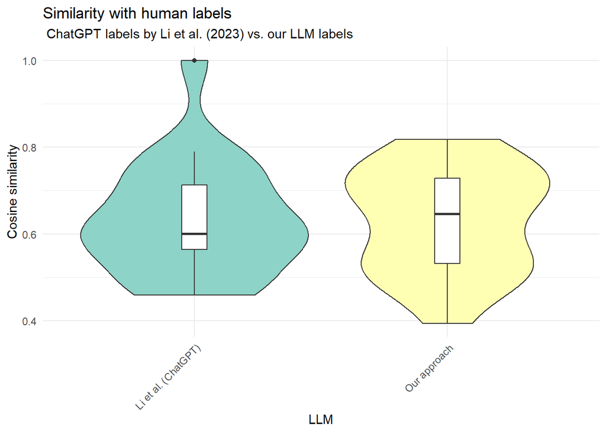

```r
# Create a data frame with the vectors
data <- data.frame(
  Group = c(rep("Li et al. (ChatGPT)", length(sims_human_chatgpt)),
            rep("Our approach", length(sims[ind_Li]))),
  Value = c(sims_human_chatgpt, sims[ind_Li])
)

# violin plot
ggplot(data, aes(x = Group, y = Value, fill = Group)) +
  geom_violin() +
  geom_boxplot(width = 0.1, fill = "white") +
  scale_fill_brewer(palette = "Set3") + # Use a predefined color palette
  theme_minimal() +
  labs(title = "Similarity with human labels",
       subtitle = " ChatGPT labels by Li et al. (2023) vs. our LLM labels",
       x = "LLM",
       y = "Cosine similarity") +
  guides(fill = "none") +
  theme(axis.text.x = element_text(angle = 45, hjust = 1))
```

While ChatGPT in Li et al. gave a perfect match with one human label, the overall similarity with human labels is higher in our LLM approach. This indicates that the LLM is better at capturing the semantics of the human labels than ChatGPT.

### Examples of low similarity

Regarding the varying performance, one has to keep in mind that labels provided by the authors do not necessarily have to be the best possible labels. Let’s have a look at some examples of low similarity between humans and the LLM.

```r
# show examples of low similarity
res_low <- res[order(res$Similarity), c("Human_Label", "LLM_Label", "Similarity", "Study", "Topic_Number")]
example <- cbind(res_low$Human_Label, res_low$LLM_Label, round(res_low$Similarity, 3))[1:10, ]
colnames(example) <- c("Human_Label", "LLM_Label", "Similarity")
example
```

```
##       Human_Label                    LLM_Label
##  [1,] "Commuting Distance"           "Tech Companies on College Campuses"
##  [2,] "Noise"                        "Victorian Jewish Literature"
##  [3,] "Steel industry"               "Financial Performance"
##  [4,] "Status/Groups"                "Social Cognition"
##  [5,] "div. activity"                "Relaxation and Hobbies"
##  [6,] "Cozy and Comfortable"         "Winter Climate"
##  [7,] "Theory"                       "Philosophical Nursing Ethics"
##  [8,] "health1"                      "Knee Pain and Control"
##  [9,] "Businesses and Organizations" "Organizational Innovation Coaching"
## [10,] "Past Health Trauma"           "Time Periods"
##       Similarity
##  [1,] "0.394"
##  [2,] "0.402"
##  [3,] "0.479"
##  [4,] "0.482"
##  [5,] "0.491"
##  [6,] "0.496"
##  [7,] "0.498"
##  [8,] "0.498"
##  [9,] "0.499"
## [10,] "0.5"
```

As we can observe, some human labels are obviously not very informative or specific, e.g. “div. activity” or “health1”, or indicate a topic that is not interpretable (“Noise”). This is a limitation of the human labels and not necessarily a limitation of the LLM. Moreover, some human labels can be better understood in the context of the study (e.g., “Past Health Trauma”). Hence, we can

1. identify and omit non-informative human labels, and
2. try to improve the performance of the LLM by providing additional context.

## Removal of non-informative human labels

### Human rating of label informativeness

To identify non-informative human labels, a human rater assessed the informativeness of the human labels. Specifically, labels were compared with the provided top terms and rated on a scale from 0 (= not at all informative) to 4 (= very informative). Let’s see which labels are considered non-informative.

```r
# table of rating results
table(human_labels$label_rating)
```

```
##
##  0  1  2  3  4
##  4  5 22 69 91
```

We will consider labels with a rating of 0 and 1 as non-informative, in total 9 labels.

```r
# show labels with informativeness = 0
res[which(human_labels$label_rating == 0),]
```

|  | Study | Topic_Number | Human_Label | LLM_Label | Similarity |
| --- | --- | --- | --- | --- | --- |
| 33 | Li 2023 | 10 | Alternative/Experimental | Mystery and Conflict | 0.5030687 |
| 38 | Li 2023 | 15 | High-Class Surroundings | Golf Course Architecture | 0.5369272 |
| 39 | Li 2023 | 16 | Commuting Distance | Tech Companies on College Campuses | 0.3935994 |
| 178 | Heiberger 2021 | 47 | Noise | Victorian Jewish Literature | 0.4023069 |

The mean similarity of these labels is 0.459. We can see that the mean similarity of these labels is lower than the mean similarity of all labels, which is 0.675.

```r
# show labels with informativeness = 1
res[which(human_labels$label_rating == 1),]
```

|  | Study | Topic_Number | Human_Label | LLM_Label | Similarity |
| --- | --- | --- | --- | --- | --- |
| 23 | Bittermann 2023 | 23 | Social Cognition | Causal Consumer Food Decisions | 0.6093025 |
| 35 | Li 2023 | 12 | Cozy and Comfortable | Winter Climate | 0.4958055 |
| 46 | Weber 2021 | 3 | health1 | Knee Pain and Control | 0.4975656 |
| 47 | Weber 2021 | 4 | health2 | Mobility Problems | 0.5275676 |
| 54 | Weber 2021 | 11 | play golf etc. | Sports and Hobbies | 0.7401768 |

The mean similarity of these labels is 0.574. We can see that the mean similarity of these labels is also lower than the mean similarity of all labels, which is 0.675.

### Similarity results without non-informative labels

```r
# indices of low informative human labels
ind_low_informative <- which(human_labels$label_rating %in% c(0, 1))

# result table without these labels
res_low_removed <- res[-ind_low_informative,]
```

### Overall similarity

```r
summary(res_low_removed$Similarity)
```

```
##    Min. 1st Qu.  Median    Mean 3rd Qu.    Max.
##  0.4793  0.5888  0.6754  0.6827  0.7497  1.0000
```

As we can see, the removal of non-informative labels increases the mean similarity of human and LLM labels from 0.675 to 0.683.

### Comparing violin plots

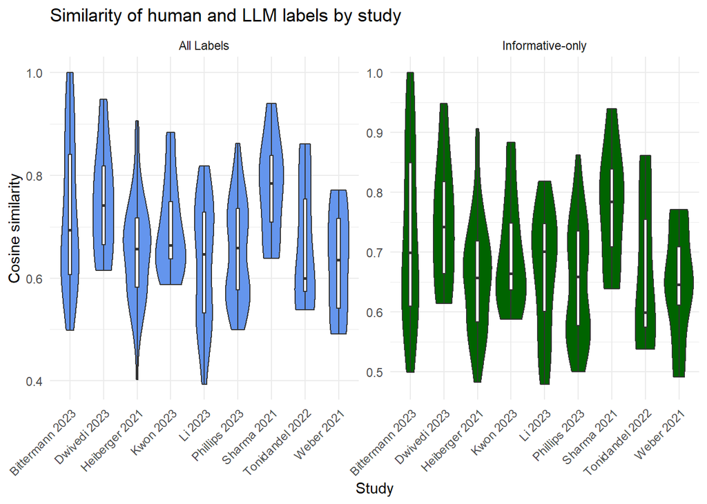

```r
library(ggplot2)

# Add a grouping variable to each dataset
res$Group <- "All Labels"
res_low_removed$Group <- "Informative-only"

# Combine the datasets
combined_data <- rbind(res, res_low_removed)

# Plot combined data
ggplot(combined_data, aes(x = Study, y = Similarity, fill = Group)) +
  geom_violin() +
  geom_boxplot(width = 0.1, fill = "white") +
  scale_fill_manual(values = c("All Labels" = "cornflowerblue", "Informative-only" = "darkgreen")) +
  theme_minimal() +
  labs(title = "Similarity of human and LLM labels by study",
       # subtitle = "Comparison of informative-only vs. all human labels",
       x = "Study",
       y = "Cosine similarity") +
  facet_wrap(~ Group, scales = "free") +  # Facet by the grouping variable
  theme(axis.text.x = element_text(angle = 45, hjust = 1)) +
  guides(fill = "none")
```

Studies with most non-informative labels were Li 2023 and Weber 2021 (see table above). This is reflected in their violin plots.

## Labeling with context information

```r
# vector of all contexts (in same order as studies in human_labels)
context <- c("Research on prior knowledge and learning in the fields of psychology and educational science",
             "Sociology",
             "How 50-year-olds imagine their future",
             "Racial equity in urban planning",
             "Information Management",
             "Suicide",
             "Leadership",
             "Artificial Intelligence",
             "Effects of specialization on academic career success")
```

```r
# run label_topics separately for each study

LLM_labels_context <- list()

for (i in 1:length(context)){

  # terms of each study
  study <- unique(human_labels$Study)[i]
  input <- human_labels$Top_Terms[human_labels$Study == study]

  # label_topics with context
  LLM_labels_context[[i]] <- label_topics(as.list(input), context = context[i], token = token)
}

# save
LLM_labels_context <- saveRDS(LLM_labels_context, file = paste0(path, "/LLM_labels_context.RDS"))
```

### Compute similarity of label sentence embeddings

```r
# get labels from list object
LLM_labels_context_labels <- unlist(lapply(LLM_labels_context, function(x){
  x$labels
}))
```

```r
# get embeddings
LLM_labels_context_embeddings <- get_embeddings(LLM_labels_context_labels)

# save
saveRDS(LLM_labels_context_embeddings, file = paste0(path, "/LLM_labels_context_embeddings.RDS"))
```

```r
# compute pairwise cosine similarity
sims_context <- vector()
for (i in 1:nrow(human_labels_embeddings)){
  sims_context[i] <- lsa::cosine(as.numeric(human_labels_embeddings[i,]), as.numeric(LLM_labels_context_embeddings[i,]))
}
```

```r
# result data frame
res_context <- data.frame(Study = human_labels$Study,
                  Topic_Number = human_labels$Topic_Number,
                  Human_Label = human_labels$Human_Label,
                  LLM_Label_context = LLM_labels_context_labels,
                  Similarity = sims_context)
```

### Overall similarity

**With Context**:

```r
summary(res_context$Similarity)
```

```
##    Min. 1st Qu.  Median    Mean 3rd Qu.    Max.
##  0.4023  0.5967  0.6836  0.6826  0.7614  1.0000
```

The context improved the performance in contrast to the previous results:

**Without Context**:

```r
summary(res$Similarity)
```

```
##    Min. 1st Qu.  Median    Mean 3rd Qu.    Max.
##  0.3936  0.5857  0.6679  0.6752  0.7449  1.0000
```

**Informative Labels only**:

```r
summary(res_low_removed$Similarity)
```

```
##    Min. 1st Qu.  Median    Mean 3rd Qu.    Max.
##  0.4793  0.5888  0.6754  0.6827  0.7497  1.0000
```

### Results by study

```r
# show mean cosine similarity by study
temp_res <- aggregate(Similarity ~ Study, data = res, FUN = mean)
temp_res_context <- aggregate(Similarity ~ Study, data = res_context, FUN = mean)
temp <- cbind(temp_res, temp_res_context[,2])
names(temp)[2:3] <- c("Similarity w/o Context", "Similarity w/ Context")
temp
```

| Study | Similarity w/o Context | Similarity w/ Context |
| --- | --- | --- |
| Bittermann 2023 | 0.7257430 | 0.7443481 |
| Dwivedi 2023 | 0.7493252 | 0.7521864 |
| Heiberger 2021 | 0.6544378 | 0.6576626 |
| Kwon 2023 | 0.6981256 | 0.6735863 |
| Li 2023 | 0.6315839 | 0.6419481 |
| Phillips 2023 | 0.6504330 | 0.6591091 |
| Sharma 2021 | 0.7742655 | 0.8032805 |
| Tonidandel 2022 | 0.6708855 | 0.6784509 |
| Weber 2021 | 0.6322067 | 0.6244904 |

```r
# show labels of Kwon 2023
res_context[res_context$Study == "Kwon 2023",3:4]
```

|  | Human_Label | LLM_Label_context |
| --- | --- | --- |
| 55 | Housing discrimination and segregation | Racial equity in urban planning |
| 56 | Opportunity neighborhoods | Racial equity in urban planning |
| 57 | Race, justice, and space | Racial equity in urban planning |
| 58 | Neighborhood change and racial integration | Racial equity in urban planning |
| 59 | School and neighborhood effects | Racial equity in urban planning |
| 60 | Social and environmental contexts in American cities | Racial equity in urban planning |
| 61 | Housing finance | Racial equity in urban planning |
| 62 | Neighborhood and urban inequality | Racial equity in urban planning |

Obviously, the LLM used the provided context as label for all topics. Let’s try a different context phrasing for these topics:

```r
# label_topics with context
Kwon_input <- human_labels$Top_Terms[human_labels$Study == "Kwon 2023"]
# Kwon_context <- "Racial equity in urban planning" # original context
Kwon_context <- "Racial Equity and Justice in Urban Studies and Planning"
Kwon_labels <- label_topics(as.list(Kwon_input), context = Kwon_context, token = token)
```

```
## Labeling 8 topic(s) using the language model mistralai/Mixtral-8x7B-Instruct-v0.1 and a Huggingface API token.
```

```
## Labeling process finished
```

```r
Kwon_labels
```

```
## lm_topic_labels object generated using mistralai/Mixtral-8x7B-Instruct-v0.1
##  1: Racial Equity and Justice in Urban Studies and Planning [housing, household, ethnic, state, social,...]
##  2: Racial Equity and Justice in Urban Studies and Planning [neighborhood, urban, black, social, racial...]
##  3: Racial Equity and Justice in Urban Studies and Planning [neighborhood, race, housing, minority, pol...]
##  4: Racial Segregation in Housing [neighborhood, segregation, black, racial, ...]
##  5: Racial Equity and Justice in Urban Studies and Planning [urban, housing, social, school, public, ci...]
##  6: Racial Equity and Justice in Urban Studies and Planning [racial, urban, city, community, housing, p...]
##  7: Racial Discrimination in Mortgage Lending [racial, discrimination, mortgage, loan, le...]
##  8: Racial Equity and Justice in Urban Studies and Planning [city, housing, urban, park, neighborhood, ...]
```

### Comparing violin plots

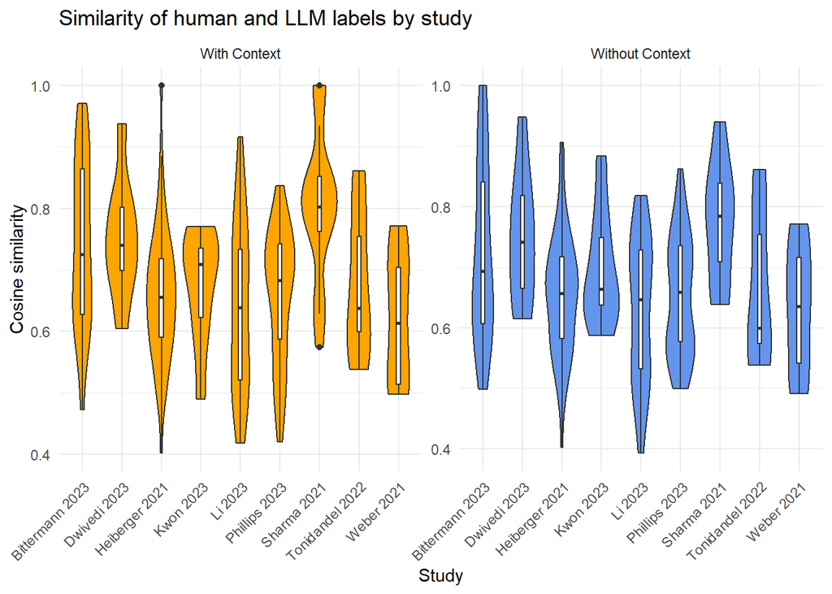

```r
library(ggplot2)

# Add a grouping variable to each dataset
res$Group <- "Without Context"
res_context$Group <- "With Context"

# allign names
names(res_context) <- names(res)

# Combine the datasets
combined_data <- rbind(res, res_context)

# Plot combined data
ggplot(combined_data, aes(x = Study, y = Similarity, fill = Group)) +
  geom_violin() +
  geom_boxplot(width = 0.1, fill = "white") +
  scale_fill_manual(values = c("Without Context" = "cornflowerblue", "With Context" = "orange")) +
  theme_minimal() +
  labs(title = "Similarity of human and LLM labels by study",
       # subtitle = "Comparison of informative-only vs. all human labels",
       x = "Study",
       y = "Cosine similarity") +
  facet_wrap(~ Group, scales = "free") +  # Facet by the grouping variable
  theme(axis.text.x = element_text(angle = 45, hjust = 1)) +
  guides(fill = "none")
```

The violin plots indicate that the context information improved the performance of the LLM, but single topics are less similar to the human labels than without context.

# Conclusion

Overall, the topics generated by the LLM show a satisfactory similarity to the human labels, especially when omitting non-informative human labels. The context information improved the performance of the LLM in most studies. However, the LLM sometimes used the context information as label for all topics.

Automated topic labels can be a valuable tool for researchers to quickly get an overview of the topics in a corpus. However, the LLM-generated labels should be used with caution and only as complementary tool to human judgement and proper topic validation.

# References

Bittermann, A., McNamara, D., Simonsmeier, B.A., & Schneider, M. (2023). The Landscape of Research on Prior Knowledge and Learning: a Bibliometric Analysis. Educational Psychology Review, 35, 58. https://doi.org/10.1007/s10648-023-09775-9

Dwivedi, Y. K., Sharma, A., Rana, N. P., Giannakis, M., Goel, P., & Dutot, V. (2023). Evolution of artificial intelligence research in Technological Forecasting and Social Change: Research topics, trends, and future directions. Technological Forecasting and Social Change, 192, 122579. https://doi.org/10.1016/j.techfore.2023.122579

Grün, B., & Hornik, K. (2024). topicmodels: Topic models [R package version 0.2-16]. Retrieved from https://CRAN.R-project.org/package=topicmodels

Heiberger, R. H., Munoz-Najar Galvez, S., & McFarland, D. A. (2021). Facets of Specialization and Its Relation to Career Success: An Analysis of U.S. Sociology, 1980 to 2015. American Sociological Review, 86(6), 1164-1192. https://doi.org/10.1177/00031224211056267

Kwon, J., & Nguyen, M. T. (2023). Four Decades of Research on Racial Equity and Justice in Urban Planning. Journal of Planning Education and Research, 0(0). https://doi.org/10.1177/0739456X231156827

Li, D., Zhang, B., & Zhou, Y. (2023, July 21). Can Large Language Models (LLM) label topics from a topic model?. https://doi.org/10.31235/osf.io/23x4m

Phillips, J. A., Davidson, T. R., & Baffoe-Bonnie, M. S. (2023). Identifying latent themes in suicide among black and white adolescents and young adults using the National Violent Death Reporting System, 2013–2019. Social Science & Medicine, 334, 116144. https://doi.org/10.1016/j.socscimed.2023.116144

Rieger, J. (2020). ldaPrototype: A method in R to get a prototype of multiple latent Dirichlet allocations. Journal of Open Source Software, 5(51), 2181. https://doi.org/10.21105/joss.02181

Roberts, M. E., Stewart, B. M., & Tingley, D. (2019). stm: An R package for structural topic models. Journal of Statistical Software, 91(2), 1-40. https://doi.org/10.18637/jss.v091.i02

Sharma, A., Rana, N. P., & Nunkoo, R. (2021). Fifty years of information management research: A conceptual structure analysis using structural topic modeling. International Journal of Information Management, 58, 102316. https://doi.org/10.1016/j.ijinfomgt.2021.102316

Tonidandel, S., Summerville, K. M., Gentry, W. A., & Young, S. F. (2022). Using structural topic modeling to gain insight into challenges faced by leaders. The Leadership Quarterly, 33(5), 101576. https://doi.org/10.1016/j.leaqua.2021.101576

Weber, M. (2021). How Do 50-Year-Olds Imagine Their Future: Social Class and Gender Disparities. Sage Open, 11(4). https://doi.org/10.1177/21582440211061567

Wijffels, J. (2023). BTM: Biterm topic models for short text [R package version 0.3.7]. Retrieved from https://CRAN.R-project.org/package=BTM